# Homework 9

Carmen Canedo

28 November 2020

# Exercise 1

## Question 1: Explore the distribution of `rincome` (reported income). What makes the default bar chart hard to understand? How could you improve the plot?

Here is a default bar graph of `rincome`.

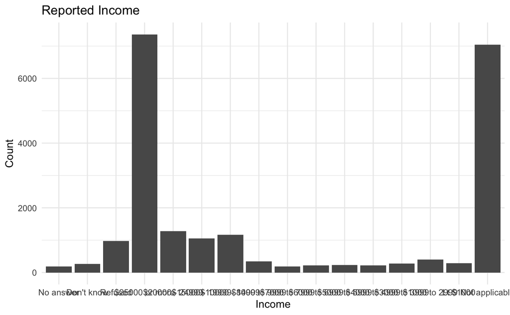

This is hard to understand because:

1. The labels on the x-axis are illegible because they are overlapping.
2. Includes “No answer” values

To improve it, I would use `coord_flip()` so that the labels are legible, remove non-response values, and sort count in ascending order.

## Question 2: What is the most common religion? Most common `partyid`?

The most common religion is Protestantism.

| relig | n |
| --- | --- |
| Protestant | 10846 |
| Catholic | 5124 |
| None | 3523 |

The most common political party is Independent. However, the levels for each party are split, so I wonder if they are combined if it would change which is the most common political party.

| partyid | n |
| --- | --- |
| Independent | 4119 |
| Not str democrat | 3690 |
| Strong democrat | 3490 |
| Not str republican | 3032 |
| Ind,near dem | 2499 |

## Question 3: Which `relig` does `denom` apply to? How can you find out with a table? How can you find out with a vizualization?

To find out what `relig` `denom` belongs to, we can check the levels to see if they give us any further details.

```
 [1] "No answer"            "Don't know"           "No denomination"      "Other"                "Episcopal"
 [6] "Presbyterian-dk wh"   "Presbyterian, merged" "Other presbyterian"   "United pres ch in us" "Presbyterian c in us"
[11] "Lutheran-dk which"    "Evangelical luth"     "Other lutheran"       "Wi evan luth synod"   "Lutheran-mo synod"
[16] "Luth ch in america"   "Am lutheran"          "Methodist-dk which"   "Other methodist"      "United methodist"
[21] "Afr meth ep zion"     "Afr meth episcopal"   "Baptist-dk which"     "Other baptists"       "Southern baptist"
[26] "Nat bapt conv usa"    "Nat bapt conv of am"  "Am bapt ch in usa"    "Am baptist asso"      "Not applicable"
```

The levels are all Protestant denominations, so we can assume that `denom` belongs to `Protestant`.

To find out with a visualization, a scatterplot can show the count of each denomination by religion, so we will use that below.

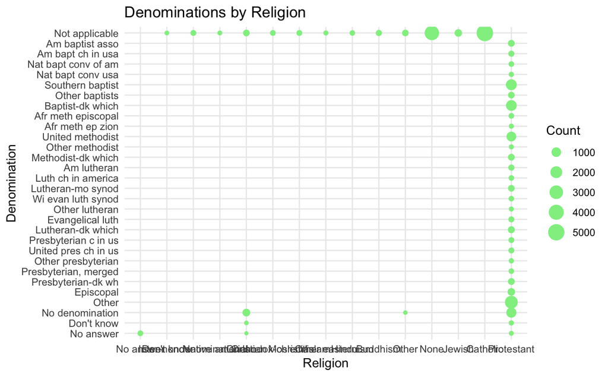

## Question 4: How have the proportions of people identifying as Democrat, Republican, and Independent changed over time?

The levels for the parties are split, so if we are going to look at their overall change, we need to combine them using `fct_collapse()`, and then we need to calculate the proportion of them by year.

| year | partyid | n |
| --- | --- | --- |
| 2000 | Other | 60 |
| 2000 | Republican | 684 |
| 2000 | Independent | 1152 |
| 2000 | Democrat | 921 |
| 2002 | Other | 84 |
| 2002 | Republican | 764 |
| 2002 | Independent | 994 |
| 2002 | Democrat | 923 |
| 2004 | Other | 41 |
| 2004 | Republican | 821 |

[output cut: 22 more lines]

Then we can create a line graph that plots the proportion of party membership overtime.

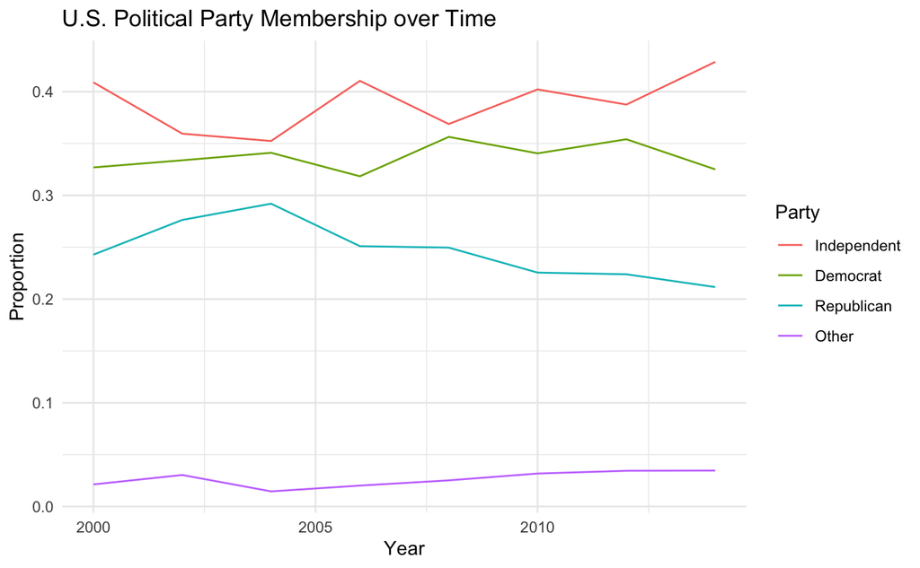

It appears that there has been an increase in individuals identifying as Independent, a decrease of people identifying as Republican, and the proportion of Democrats has remained relatively the same.

## Question 5: How could you collapse `rincome` into a small set of categories?

The levels for `rincome` are not broken down into even groups, so decrease the number of categories, I am going to try to aim for each category to increase by about $5000.

I will be using the following levels:

- $0 to $5000
- $5000 to $10000

| year | marital | age | race | rincome | partyid | relig | denom | tvhours |
| --- | --- | --- | --- | --- | --- | --- | --- | --- |
| 2000 | Never married | 26 | White | $5000 to 10000 | Ind,near rep | Protestant | Southern baptist | 12 |
| 2000 | Divorced | 48 | White | $5000 to 10000 | Not str republican | Protestant | Baptist-dk which | NA |
| 2000 | Widowed | 67 | White | Unknown | Independent | Protestant | No denomination | 2 |
| 2000 | Never married | 39 | White | Unknown | Ind,near rep | Orthodox-christian | Not applicable | 4 |
| 2000 | Divorced | 25 | White | Unknown | Not str democrat | None | Not applicable | 1 |
| 2000 | Married | 25 | White | $20000 - 24999 | Strong democrat | Protestant | Southern baptist | NA |
| 2000 | Never married | 36 | White | $25000 or more | Not str republican | Christian | Not applicable | 3 |
| 2000 | Divorced | 44 | White | $5000 to 10000 | Ind,near dem | Protestant | Lutheran-mo synod | NA |
| 2000 | Married | 44 | White | $25000 or more | Not str democrat | Protestant | Other | 0 |
| 2000 | Married | 47 | White | $25000 or more | Strong republican | Protestant | Southern baptist | 3 |

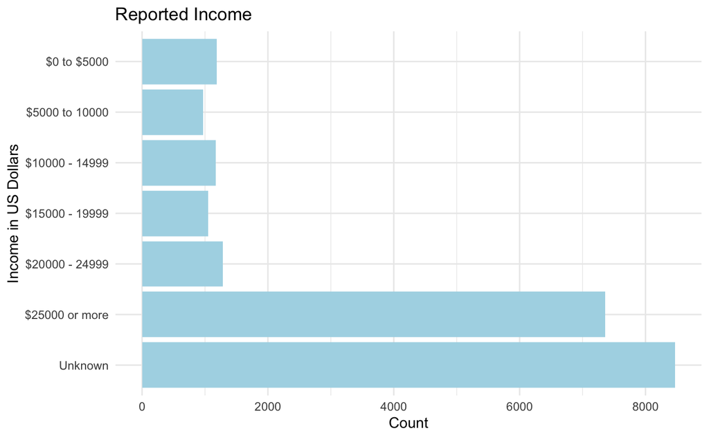

# Exercise 2

## Question 1: Parse the following date-times

```
[1] "2004-05-26 11:11:11 UTC"
```

## Question 3: For each month in `wmata_ridership`, calculate the proportion of rides made on a given day of the month. Then make box plots of the proportions of ridership vs. day of the week, *excluding any days from 2004*.

[output not shown]

[output not shown]

[output cut: 98 more lines]

[output not shown]

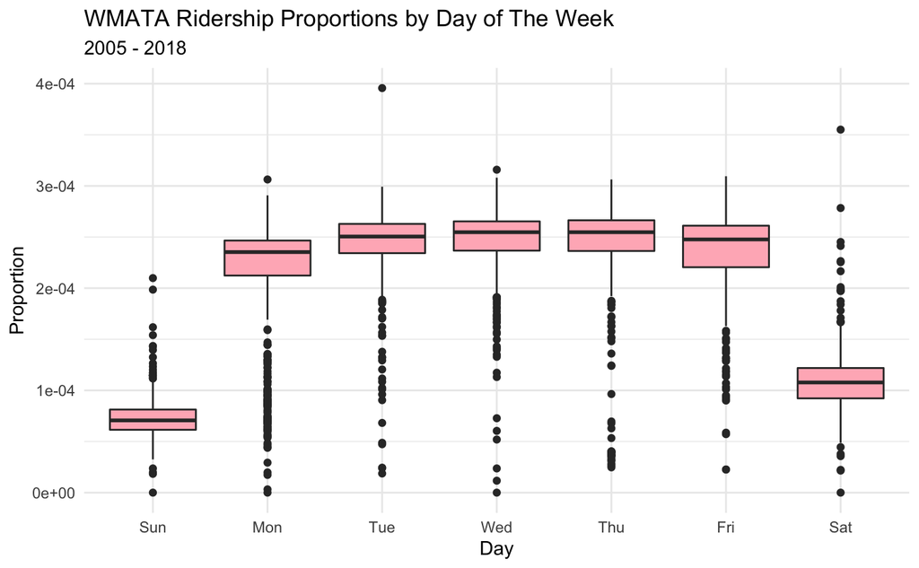

## Question 4: How long of a time-span is covered in the WMATA ridership dataset?

```
[1] "472435200s (~14.97 years)"
```